# PAEZ_CRESPO-ELSY_JOHANNA-ADA-HOMEWORK-02

Johanna Paez Crespo

26/2/2019

## MODULE 11

*CHALLANGE-01:*

1. Every Saturday, at the same time, a primatologist goes and sits in the forest in the morning and listens for titi monkey calls, counting the number of calls they hear in a 2 hour window from 5am to 7am. Based on previous knowledge, she believes that the mean number calls she will hear in that time is 15. Let X represent the appropriate Poisson random variable of the number of calls heard in each monitoring session.

1.a. What is the probability that she will hear more than 8 calls during any given session?

```r
x <- 8
l <- 15
probset <- ppois(q = x, lambda = l, lower.tail=FALSE)
probset
```

```
## [1] 0.9625535
```

1.b. What is the probability that she will hear no calls in a session?

```r
x <- 0
l <- 15
nocalls <- dpois(x = x, lambda = l)
nocalls
```

```
## [1] 3.059023e-07
```

1.c. What is the probability that she will hear exactly 3 calls in a session?

```r
x <- 3
l <- 15
threecalls <- dpois(x = x, lambda = l)
threecalls
```

```
## [1] 0.0001720701
```

1.d. Plot the relevant Poisson mass function over the values in range 0 ≤ x ≤ 30.

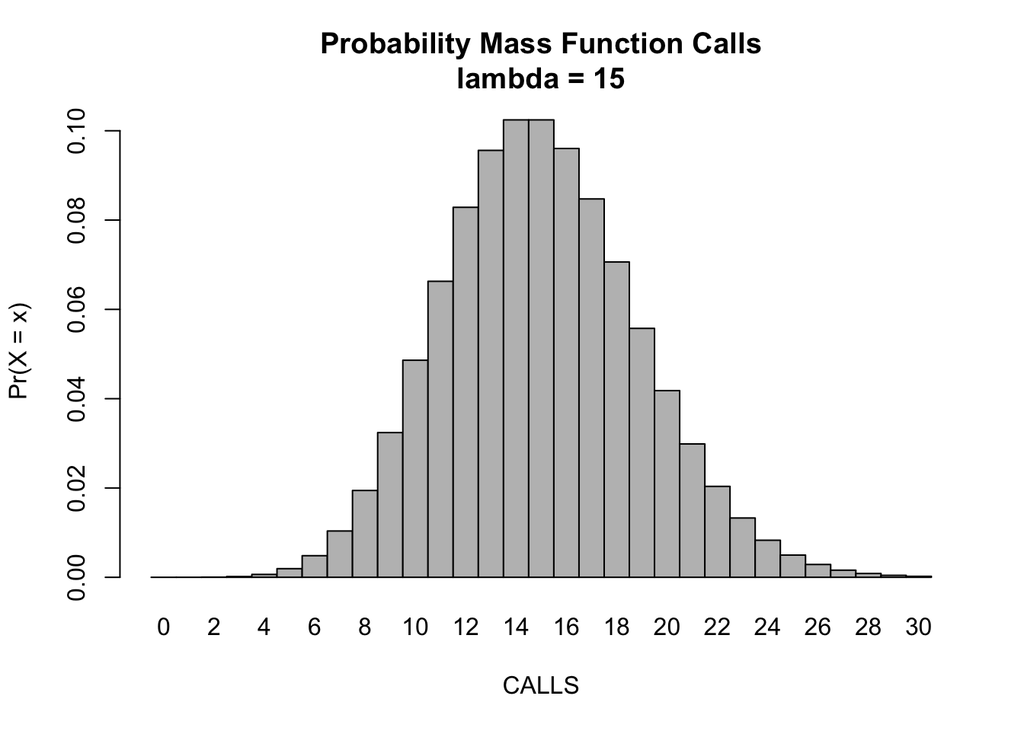

```r
x <- 0:30
l = 15
probset <- dpois(x = x, lambda = l)
barplot(probset, names.arg = x, space = 0, xlab = "CALLS", ylab = "Pr(X = x)", main = paste0("Probability Mass Function Calls\nlambda = ",l))
```

1.e. Simulate 104 results from this distribution (i.e., 2 years of Saturday monitoring sessions).

```r
n <- 104
l <- 15
simulation <- rpois(n = n, lambda = l)
simulation
```

```
##   [1] 17 20 13 24 15 10 16 17 14 17 17 13 12 11 14 16 12 19 18 11 16 15 23
##  [24] 18 15  3 15 19 15 14 15 12 18 11 16 17 14 16 12 18 10 18 12 18 15 15
##  [47] 13 12  9 13 14 14 14 16 12 10 17 23 12 13 18 21 17 12 19 13 12 18 19
##  [70] 15 19 12 10 14 19 14 11 18 13 13 18 22 16 17 15 18 16 19 13  8 15 13
##  [93] 15 15 14 14 18 18 15 15 15 13 19 19
```

1.f. Plot the simulated results using hist() and use xlim() to set the horizontal limits to be from 0 to 30. How does your histogram compare to the shape of the probability mass function you plotted above?

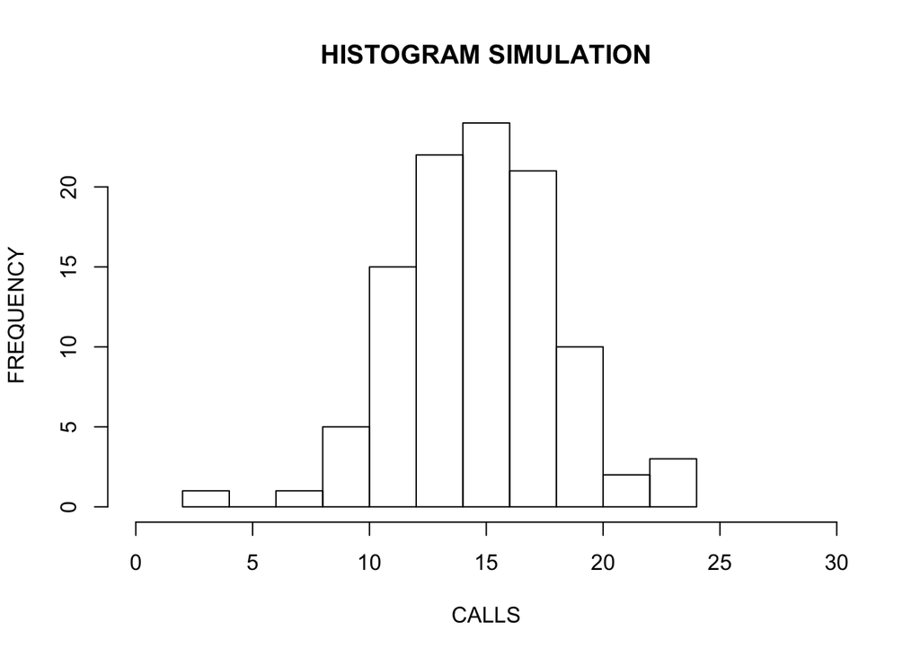

```r
hist(simulation, main = "HISTOGRAM SIMULATION",
     xlab = "CALLS", ylab = "FREQUENCY", xlim = c(0,30))
```

*CHALLANGE-02:*

2. Load in the dataset “zombies.csv” from my GitHub repository at https://github.com/difiore/ADA-2019. This data includes the first and last name and gender of the entire population of 1000 people who have survived the zombie apocalypse and are now ekeing out an existence somewhere on the East Coast, along with several other variables (height, weight, age, number of years of education, number of zombies they have killed, and college major see here for info on important post-zombie apocalypse majors

```r
library(curl)
library(dplyr)
a <- curl("https://raw.githubusercontent.com/difiore/ADA-2019/master/zombies.csv")
b <- read.csv(a, header = TRUE, sep = ",", stringsAsFactors = FALSE)
DataSet <- select(b, id, height, weight, age, zombies_killed, years_of_education)
head(DataSet)
```

```
##   id   height   weight      age zombies_killed years_of_education
## 1  1 62.88951 132.0872 17.64275              2                  1
## 2  2 67.80277 146.3753 22.58951              5                  3
## 3  3 72.12908 152.9370 21.91276              1                  1
## 4  4 66.78484 129.7418 18.19058              5                  6
## 5  5 64.71832 132.4265 21.10399              4                  3
## 6  6 71.24326 152.5246 21.48355              1                  4
```

2.a. Calculate the population mean and standard deviation for each quantitative random variable (height, weight, age, number of zombies killed, and years of education).

```r
MEANS <- summarise(DataSet, MeanH = mean(DataSet$height, na.rm = TRUE),
                   MeanW = mean(DataSet$weight, na.rm = TRUE),
                   MeanA = mean(DataSet$age, na.rm = TRUE),
                   MeanZK = mean(DataSet$zombies_killed, na.rm=TRUE),
                   MeanYE = mean(DataSet$years_of_education, na.rm=TRUE))
MEANS
```

```
##     MeanH    MeanW    MeanA MeanZK MeanYE
## 1 67.6301 143.9075 20.04696  2.992  2.996
```

```r
sigma <- function(x) {sqrt(sum((x - mean(x))^2)/length(x))}
sigma <- summarise(DataSet, sigmaH = sigma(DataSet$height),
                            sigmaW = sigma(DataSet$weight),
                            sigmaA = sigma(DataSet$age),
                            sigmaZK = sigma(DataSet$zombies_killed),
                            sigmaYE = sigma(DataSet$years_of_education))
sigma
```

```
##    sigmaH   sigmaW   sigmaA  sigmaZK  sigmaYE
## 1 4.30797 18.39186 2.963583 1.747551 1.675704
```

or

```r
sigma <- sqrt(sum((x - mean(x))^2)/length(x))
sigma <- summarise(DataSet, sigmaH = sqrt(sum((DataSet$height - mean(DataSet$height))^2)/length(DataSet$height)),
                            sigmaW = sqrt(sum((DataSet$weight - mean(DataSet$weight))^2)/length(DataSet$weight)),
                            sigmaA = sqrt(sum((DataSet$age - mean(DataSet$age))^2)/length(DataSet$age)),
                            sigmaZK = sqrt(sum((DataSet$zombies_killed - mean(DataSet$zombies_killed))^2)/length(DataSet$zombies_killed)),
                            sigmaYE = sqrt(sum((DataSet$years_of_education - mean(DataSet$years_of_education))^2)/length(DataSet$years_of_education)))
sigma
```

```
##    sigmaH   sigmaW   sigmaA  sigmaZK  sigmaYE
## 1 4.30797 18.39186 2.963583 1.747551 1.675704
```

2.b. Use {ggplot} and make boxplots of each of these variables by gender.

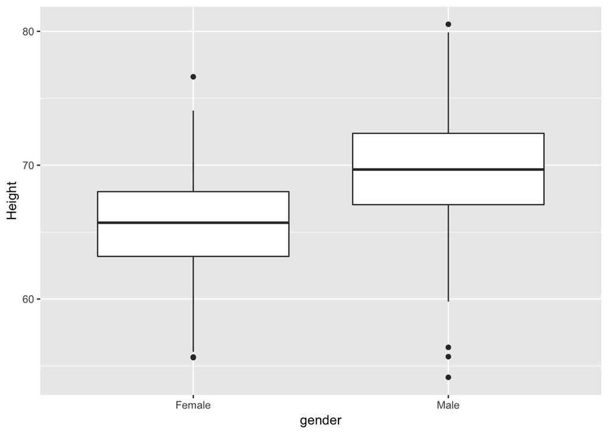

```r
library(ggplot2)
pH <- ggplot(data = b, aes(x = gender, y = height))
pH <- pH + geom_boxplot(na.rm = TRUE)
pH <- pH + ylab("Height")
pH
```

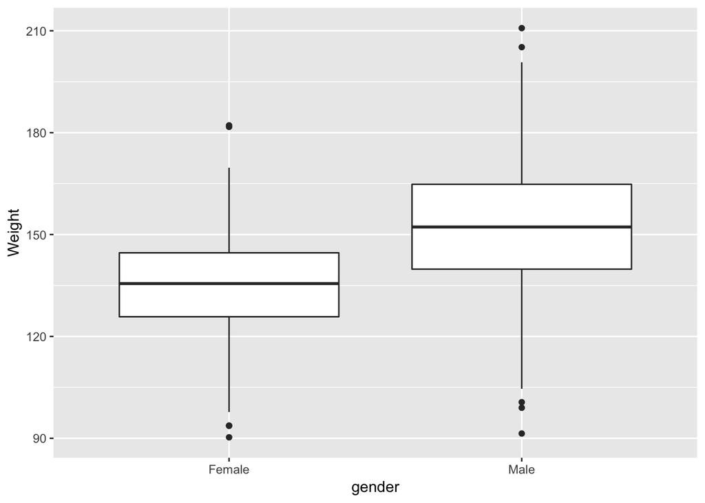

```r
pW <- ggplot(data = b, aes(x = gender, y = weight))
pW <- pW + geom_boxplot(na.rm = TRUE)
pW <- pW + ylab("Weight")
pW
```

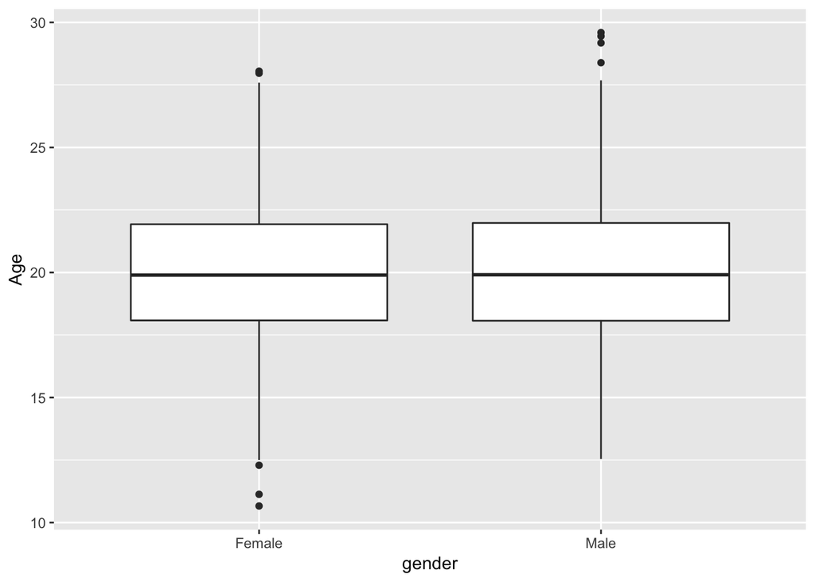

```r
pA <- ggplot(data = b, aes(x = gender, y = age))
pA <- pA + geom_boxplot(na.rm = TRUE)
pA <- pA + ylab("Age")
pA
```

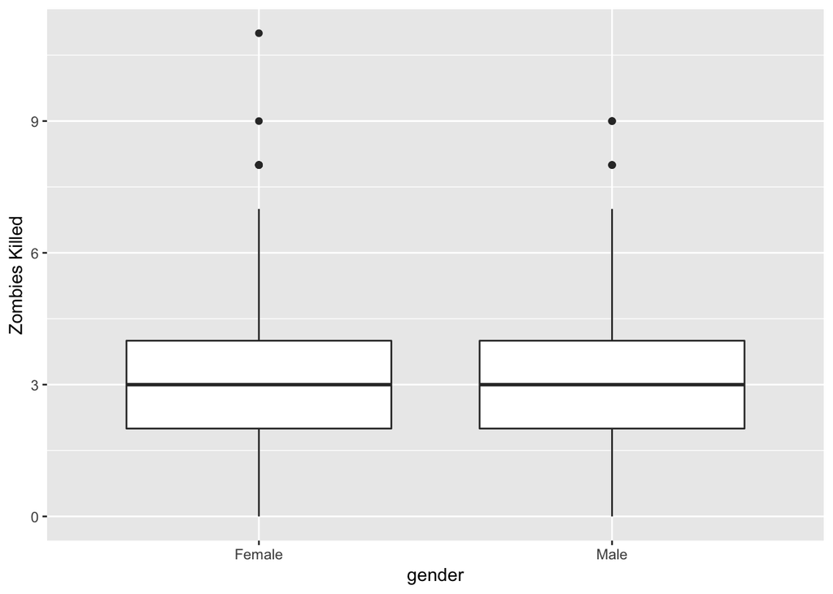

```r
pZK <- ggplot(data = b, aes(x = gender, y = zombies_killed))
pZK <- pZK + geom_boxplot(na.rm = TRUE)
pZK <- pZK + ylab("Zombies Killed")
pZK
```

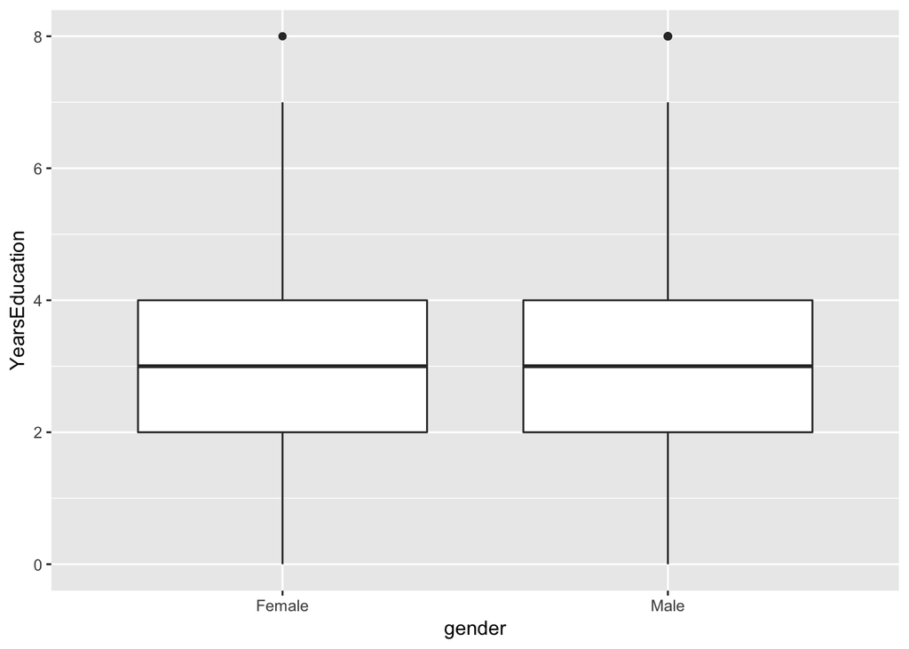

```r
pYE <- ggplot(data = b, aes(x = gender, y = years_of_education))
pYE <- pYE + geom_boxplot(na.rm = TRUE)
pYE <- pYE + ylab("YearsEducation")
pYE
```

2.c. Use {ggplot} and make scatterplots of height and weight in relation to age. Do these variables seem to be related? In what way?

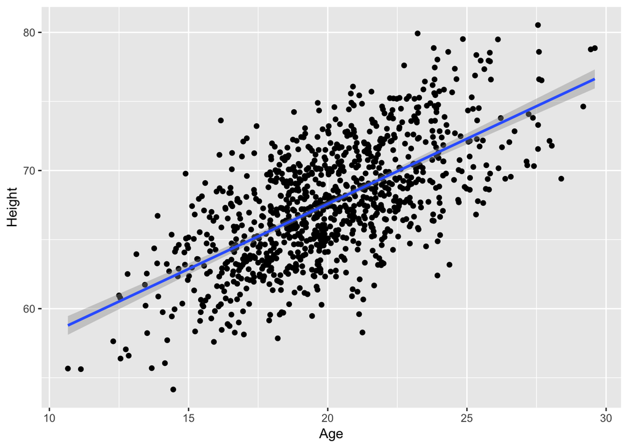

```r
p <- ggplot(data = b, aes(x = age, y = height))
p <- p + xlab("Age") + ylab("Height")
p <- p + geom_point(na.rm = TRUE)
p <- p + geom_smooth(method = "lm", fullrange = FALSE, na.rm = TRUE)
p
```

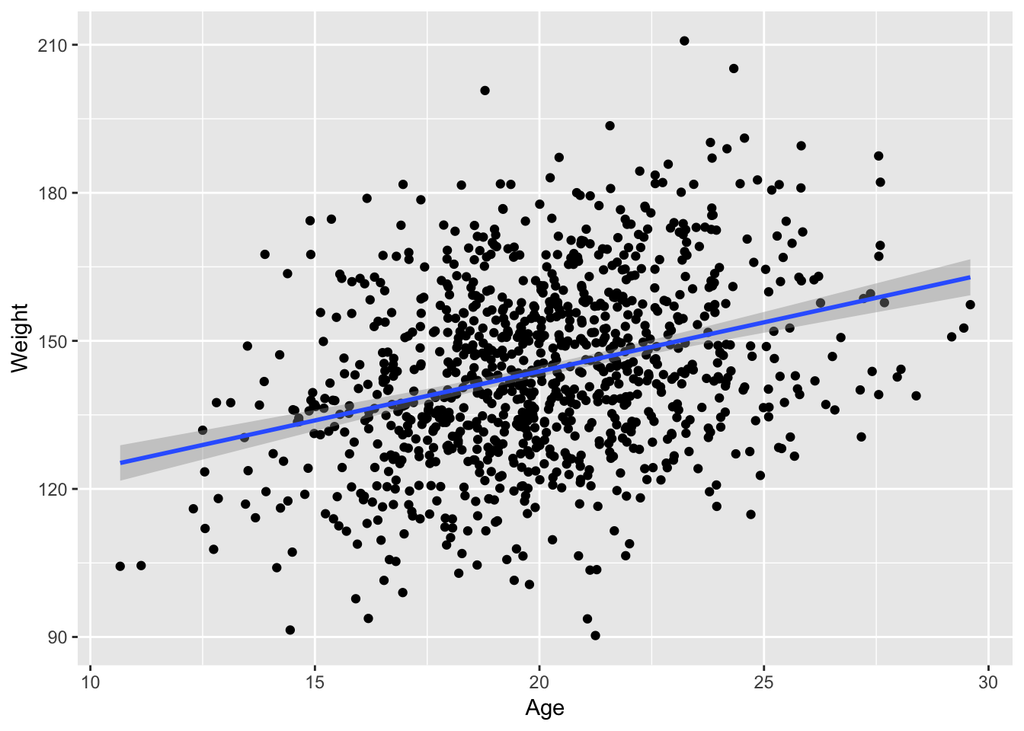

```r
p <- ggplot(data = b, aes(x = age, y = weight))
p <- p + xlab("Age") + ylab("Weight")
p <- p + geom_point(na.rm = TRUE)
p <- p + geom_smooth(method = "lm", fullrange = FALSE, na.rm = TRUE)
p
```

*In both scatterplots variables (height and weight) seem to be related with age. As age increase, both (height and weight) increase*

2.d. Using histograms and Q-Q plots, check whether the quantitative variables seem to be drawn from a normal distribution. Which seem to be and which do not?

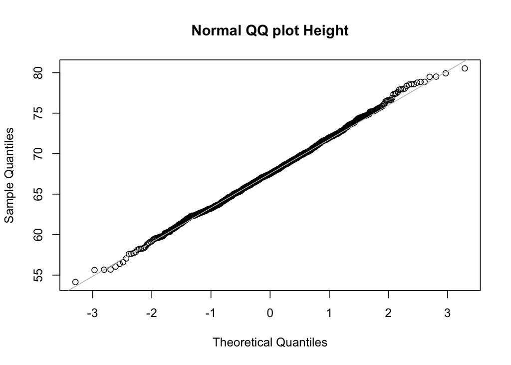

```r
qqnorm(b$height, main = "Normal QQ plot Height")
qqline(b$height, col = "gray")
```

*Height seem to be drawn from a normal distribution*

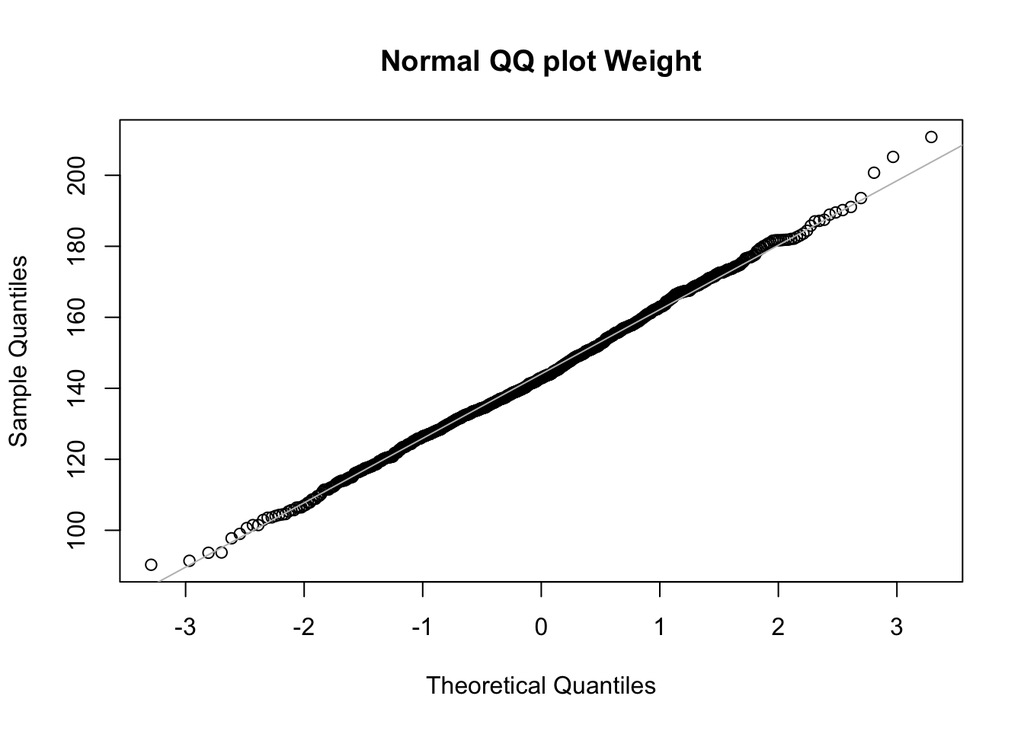

```r
qqnorm(b$weight, main = "Normal QQ plot Weight")
qqline(b$weight, col = "gray")
```

*Weight seem to be drawn from a normal distribution*

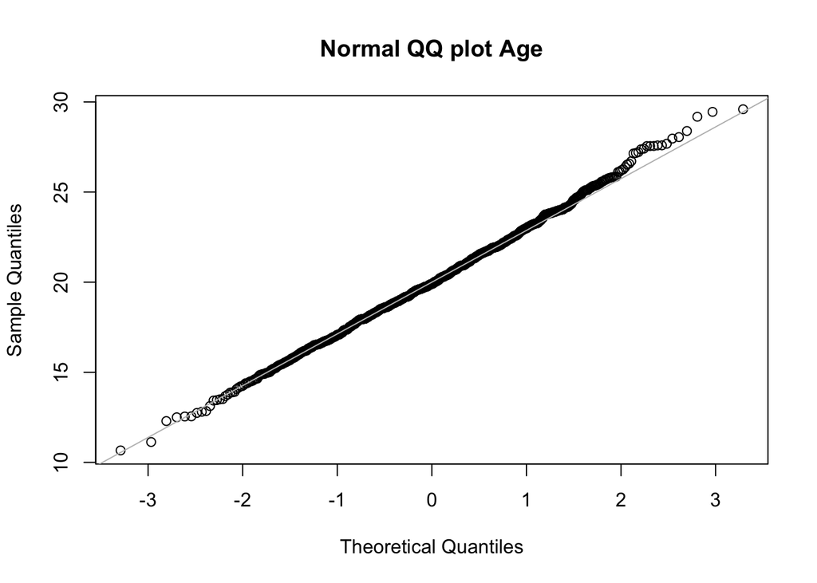

```r
qqnorm(b$age, main = "Normal QQ plot Age")
qqline(b$age, col = "gray")
```

*Age seem to be drawn from a normal distribution*

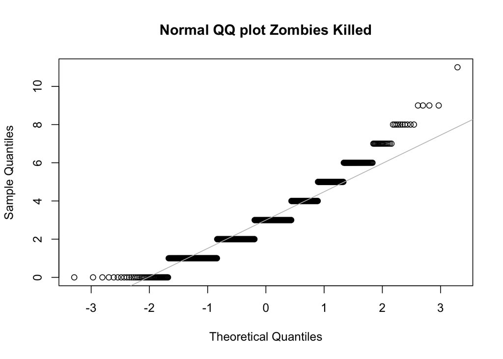

```r
qqnorm(b$zombies_killed, main = "Normal QQ plot Zombies Killed")
qqline(b$zombies_killed, col = "gray")
```

*Zombies Killed seem to be drawn from a poisson distribution*

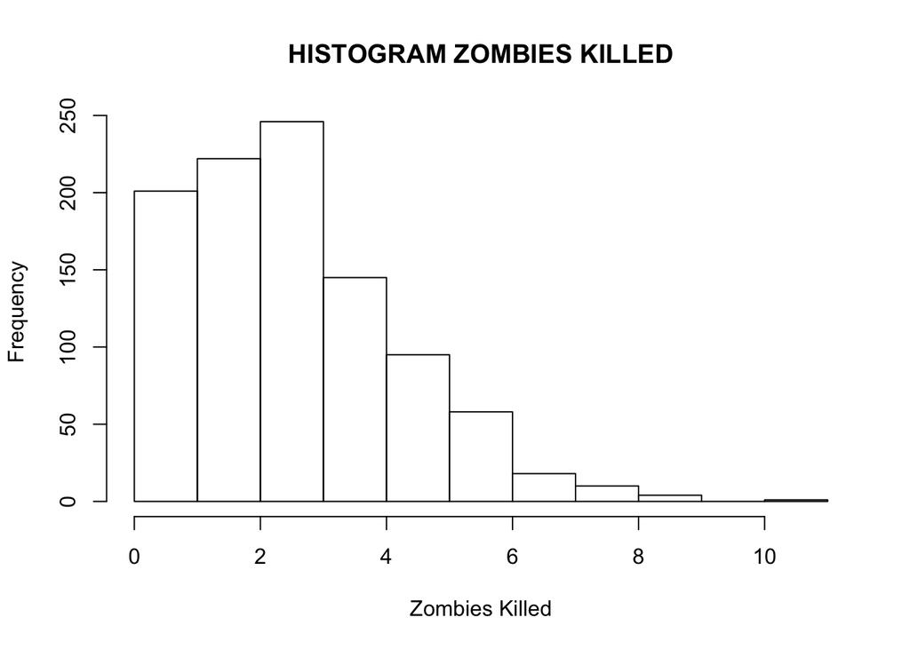

```r
hist(b$zombies_killed, main= "HISTOGRAM ZOMBIES KILLED", xlab="Zombies Killed")
```

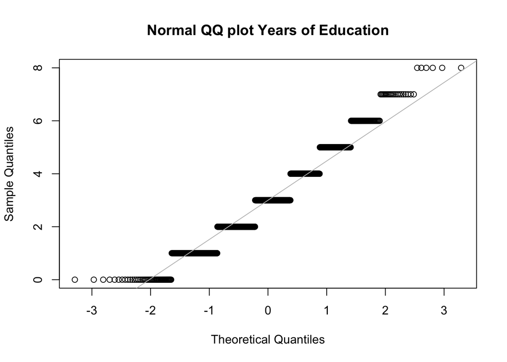

```r
qqnorm(b$years_of_education, main = "Normal QQ plot Years of Education")
qqline(b$years_of_education, col = "gray")
```

*Years of Education seem to be drawn from a poisson distribution*

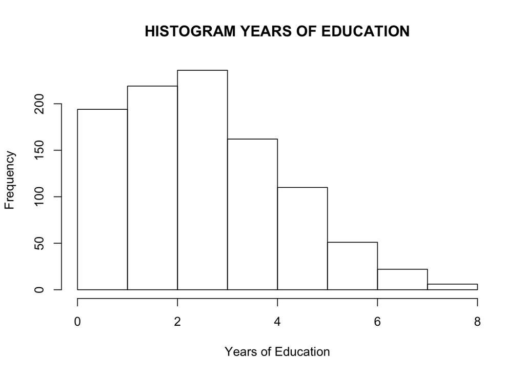

```r
hist(b$years_of_education, main= "HISTOGRAM YEARS OF EDUCATION", xlab="Years of Education")
```

2.e. Now use the sample() function to sample ONE subset of 30 zombie apocalypse survivors (without replacement) from this population and calculate the mean and sample standard deviation for each variable. Also estimate the standard error for each variable and construct the 95% confidence interval for each mean. Note that for the variables that are not drawn from the normal distribution, you will need to base your estimate of the CIs on some different distribution!

```r
sursample <- NULL
sursample <- sample_n(DataSet, size = 30, replace = FALSE)
head(sursample)
```

```
##      id   height   weight      age zombies_killed years_of_education
## 871 871 63.08010 125.5156 17.68825              3                  2
## 550 550 67.41345 142.0773 16.57199              3                  5
## 90   90 70.55803 162.3951 21.93253              3                  3
## 380 380 66.03250 137.3454 16.91755              2                  1
## 129 129 70.26668 154.6746 20.24323              2                  3
## 582 582 64.05988 135.8560 17.52440              3                  5
```

2.e.a. Calculating Mean for each cuantitative variable

```r
MEANS_surv <- summarise(sursample, Mean_H = mean(sursample$height), Mean_W = mean(sursample$weight), Mean_A = mean(sursample$age), Mean_ZK = mean(sursample$zombies_killed), Mean_YE = mean(sursample$years_of_education))
MEANS_surv
```

```
##     Mean_H   Mean_W   Mean_A Mean_ZK Mean_YE
## 1 66.73174 138.1873 19.65848     2.4     2.6
```

2.e.b. Calculating Standard Deviation for each cuantitative variable

```r
SD_surv <- summarise(sursample, SD_H = sd(sursample$height), SD_W = sd(sursample$weight), SD_A = sd(sursample$age), SD_ZK = sd(sursample$zombies_killed), SD_YE = sd(sursample$years_of_education))
SD_surv
```

```
##       SD_H     SD_W     SD_A    SD_ZK    SD_YE
## 1 3.487259 13.75378 2.683623 1.328728 1.499425
```

2.e.c. Calculating Standard Error for each cuantitative variable

```r
SE <- function(x) {sd(x)/sqrt(length(x))}
SE_surv <- summarise(sursample, SE_H = SE(sursample$height), SE_W = SE(sursample$weight), SE_A = SE(sursample$age), SE_ZK = SE(sursample$zombies_killed), SE_YE = SE(sursample$years_of_education))
SE_surv
```

```
##        SE_H     SE_W      SE_A     SE_ZK     SE_YE
## 1 0.6366835 2.511084 0.4899604 0.2425914 0.2737563
```

2.e.d. Calculating 95% confidence intervals for each cuantitative variable

#### HEIGHT

```r
qnorm(0.975, mean = MEANS_surv$Mean_H, sd = SD_surv$SD_H)
```

```
## [1] 73.56664
```

```r
up_height <- MEANS_surv$Mean_H + qnorm(0.975) * SE_surv$SE_H
low_height <- MEANS_surv$Mean_H - qnorm(0.975) * SE_surv$SE_H
CI_height <- c(low_height, up_height)
```

```r
CI_height
```

```
## [1] 65.48386 67.97962
```

#### WEIGHT

```r
qnorm(0.975, mean = MEANS_surv$Mean_W, sd = SD_surv$SD_W)
```

```
## [1] 165.1442
```

```r
up_weight <- MEANS_surv$Mean_W + qnorm(0.975) * SE_surv$SE_W
low_weight <- MEANS_surv$Mean_W - qnorm(0.975) * SE_surv$SE_W
CI_weight <- c(low_weight, up_weight)
```

```r
CI_weight
```

```
## [1] 133.2657 143.1089
```

#### AGE

```r
qnorm(0.975, mean = MEANS_surv$Mean_A, sd = SD_surv$SD_A)
```

```
## [1] 24.91829
```

```r
up_age <- MEANS_surv$Mean_A + qnorm(0.975) * SE_surv$SE_A
low_age <- MEANS_surv$Mean_A - qnorm(0.975) * SE_surv$SE_A
CI_age <- c(low_age, up_age)
```

```r
CI_age
```

```
## [1] 18.69818 20.61879
```

#### ZOMBIES KILLED

```r
qpois(0.975, lambda = MEANS_surv$Mean_ZK)
```

```
## [1] 6
```

```r
up_zombieskilled <- mean(MEANS_surv$Mean_ZK) + qpois(0.975, lambda = mean(MEANS_surv$Mean_ZK) * SE_surv$SE_ZK)
low_zombieskilled <- mean(MEANS_surv$Mean_ZK) - qpois(0.975, lambda = mean(MEANS_surv$Mean_ZK) * SE_surv$SE_ZK)
CI_zombieskilled <- c(low_zombieskilled, up_zombieskilled)
```

```r
CI_zombieskilled
```

```
## [1] 0.4 4.4
```

#### YEARS OF EDUCATION

```r
qpois(0.975, lambda = MEANS_surv$Mean_YE)
```

```
## [1] 6
```

```r
up_yearsedu <- mean(MEANS_surv$Mean_YE) + qpois(0.975, lambda = mean(MEANS_surv$Mean_YE) * SE_surv$SE_YE)
low_yearsedu <- mean(MEANS_surv$Mean_YE) - qpois(0.975, lambda = mean(MEANS_surv$Mean_YE) * SE_surv$SE_YE)
CI_yearsedu <- c(low_yearsedu, up_yearsedu)
```

```r
CI_yearsedu
```

```
## [1] -0.4  5.6
```

2.f. Now draw 99 more random samples of 30 zombie apocalypse survivors out and calculate the mean for each of the these samples. Together with the first sample you drew out, you now have a set of 100 means for each variable (each based on 30 observations), which constitutes a sampling distribution for each variable. What are the means and standard deviations of the sampling distribution for each variable? How do the standard deviations compare to the standard errors estimated in [2.e.]? What do these sampling distributions look like? Are they normally distributed? What about for those variables that you concluded were not originally drawn from a normal distribution?

#### Drawing 99 more random samples

```r
k <- 99
n <- 30
SUR_99 <- NULL
SUR_99meanheight <- NULL
SUR_99meanweight <- NULL
SUR_99meanage <- NULL
SUR_99meanzombieskilled <- NULL
SUR_99meanyearsedu <- NULL

for (i in 1:99) {
  SUR_99 <- sample_n(DataSet, size = n, replace=FALSE)
  SUR_99meanheight[i] <- mean(SUR_99$height)
  SUR_99meanweight[i] <- mean(SUR_99$weight)
  SUR_99meanage[i] <- mean(SUR_99$age)
  SUR_99meanzombieskilled[i] <- mean(SUR_99$zombies_killed)
  SUR_99meanyearsedu[i] <- mean(SUR_99$years_of_education)
}
```

#### Creating DataFrame (from 99 random samples):

```r
mydata <- data.frame(SUR_99meanheight, SUR_99meanweight,
                     SUR_99meanage, SUR_99meanzombieskilled, SUR_99meanyearsedu)
tail(mydata)
```

```
##    SUR_99meanheight SUR_99meanweight SUR_99meanage SUR_99meanzombieskilled
## 94         69.18996         148.7366      21.15322                2.933333
## 95         67.37942         146.6838      19.72583                2.766667
## 96         65.96311         138.2703      19.09540                2.633333
## 97         67.14777         145.6381      19.16346                3.066667
## 98         67.05358         143.3638      19.37533                3.266667
## 99         67.86651         143.7778      19.94429                3.000000
##    SUR_99meanyearsedu
## 94           2.766667
## 95           2.333333
## 96           2.766667
## 97           2.600000
## 98           2.866667
## 99           3.833333
```

#### First sample variables

```r
sample_sur <- c(MEANS_surv$Mean_H, MEANS_surv$Mean_W, MEANS_surv$Mean_A,
                MEANS_surv$Mean_ZK, MEANS_surv$Mean_YE)
sample_sur
```

```
## [1]  66.73174 138.18729  19.65848   2.40000   2.60000
```

#### Creating a sample distribution

```r
sampledist <- rbind(mydata, sample_sur)
tail(sampledist)
```

```
##     SUR_99meanheight SUR_99meanweight SUR_99meanage
## 95          67.37942         146.6838      19.72583
## 96          65.96311         138.2703      19.09540
## 97          67.14777         145.6381      19.16346
## 98          67.05358         143.3638      19.37533
## 99          67.86651         143.7778      19.94429
## 100         66.73174         138.1873      19.65848
##     SUR_99meanzombieskilled SUR_99meanyearsedu
## 95                 2.766667           2.333333
## 96                 2.633333           2.766667
## 97                 3.066667           2.600000
## 98                 3.266667           2.866667
## 99                 3.000000           3.833333
## 100                2.400000           2.600000
```

2.f.a. What are the means and standard deviations of the sampling distribution for each variable?

#### MEANS

```r
MEANS_samdis <- summarise(sampledist, Mean_samdisH = mean(sampledist$SUR_99meanheight),
                          Mean_samdisW = mean(sampledist$SUR_99meanweight),
                          Mean_samdisA = mean(sampledist$SUR_99meanage),
                          Mean_samdisZK = mean(sampledist$SUR_99meanzombieskilled),
                          Mean_samdisYE = mean(sampledist$SUR_99meanyearsedu))
MEANS_samdis
```

```
##   Mean_samdisH Mean_samdisW Mean_samdisA Mean_samdisZK Mean_samdisYE
## 1     67.56984      143.689      20.0432      3.039333      2.999667
```

#### STANDARD DEVIATIONS

```r
SD_samdis <- summarise(sampledist, SD_samdisH = sd(sampledist$SUR_99meanheight),
                       SD_samdisW = sd(sampledist$SUR_99meanweight),
                       SD_samdisA = sd(sampledist$SUR_99meanage),
                       SD_samdisZK = sd(sampledist$SUR_99meanzombieskilled),
                       SD_samdisYE = sd(sampledist$SUR_99meanyearsedu))
SD_samdis
```

```
##   SD_samdisH SD_samdisW SD_samdisA SD_samdisZK SD_samdisYE
## 1  0.8595524   3.434274  0.6103712   0.3209966   0.3146086
```

#### STANDARD ERRORS

```r
SE <- function(x) {sd(x)/sqrt(length(x))}
SE_samdis <- summarise(sampledist, SE_samdisH = SE(sampledist$SUR_99meanheight),
                       SE_samdisW = SE(sampledist$SUR_99meanweight),
                       SE_samdisA = SE(sampledist$SUR_99meanage),
                       SE_samdisZK = SE(sampledist$SUR_99meanzombieskilled),
                       SE_samdisYE = SE(sampledist$SUR_99meanyearsedu))
SE_samdis
```

```
##   SE_samdisH SE_samdisW SE_samdisA SE_samdisZK SE_samdisYE
## 1 0.08595524  0.3434274 0.06103712  0.03209966  0.03146086
```

2.f.b. How do the standard deviations compare to the standard errors estimated in [2.e.]?

```r
SE_surv
```

```
##        SE_H     SE_W      SE_A     SE_ZK     SE_YE
## 1 0.6366835 2.511084 0.4899604 0.2425914 0.2737563
```

```r
SD_samdis
```

```
##   SD_samdisH SD_samdisW SD_samdisA SD_samdisZK SD_samdisYE
## 1  0.8595524   3.434274  0.6103712   0.3209966   0.3146086
```

*SE’s of the mean and SD’s of the sample were similar. However, The standard error of the mean give us information about how far a given sample mean is likely to be from the population mean. The standard deviation of a sample measured the degree to which individual values within a sample differ from the mean for that sample.*

2.f.c. What do these sampling distributions look like? Are they normally distributed? What about for those variables that you concluded were not originally drawn from a normal distribution?

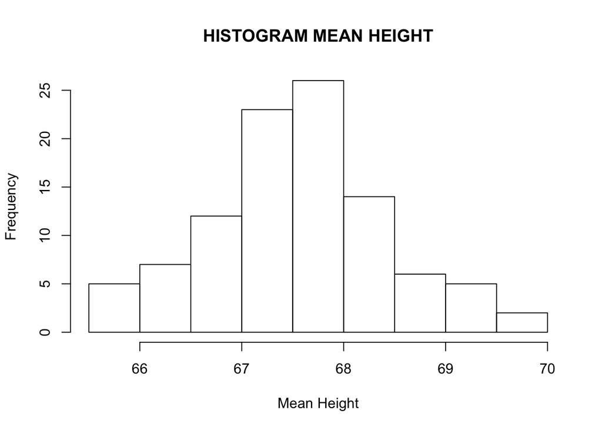

```r
hist(sampledist$SUR_99meanheight, main= "HISTOGRAM MEAN HEIGHT", xlab="Mean Height")
```

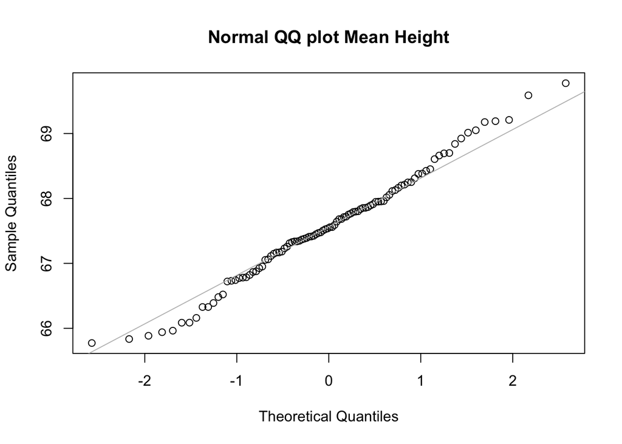

```r
qqnorm(sampledist$SUR_99meanheight, main = "Normal QQ plot Mean Height")
qqline(sampledist$SUR_99meanheight, col = "gray")
```

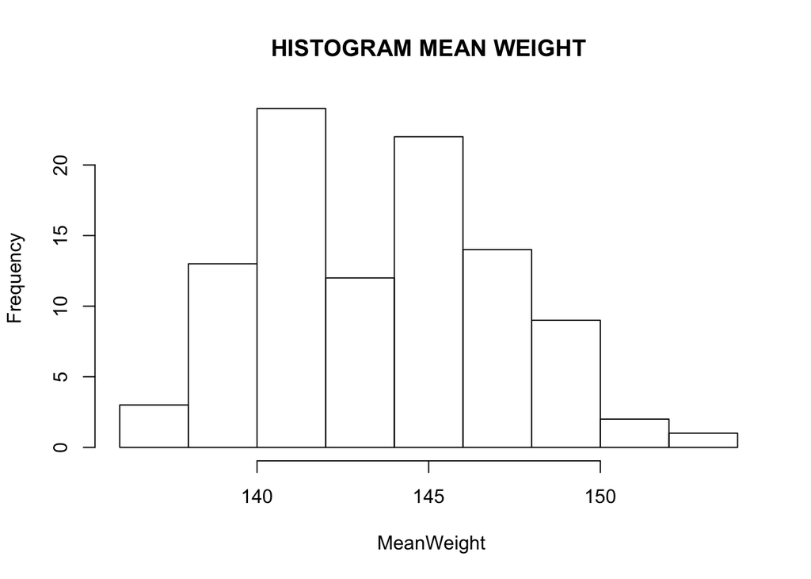

```r
hist(sampledist$SUR_99meanweight, main= "HISTOGRAM MEAN WEIGHT", xlab=" MeanWeight")
```

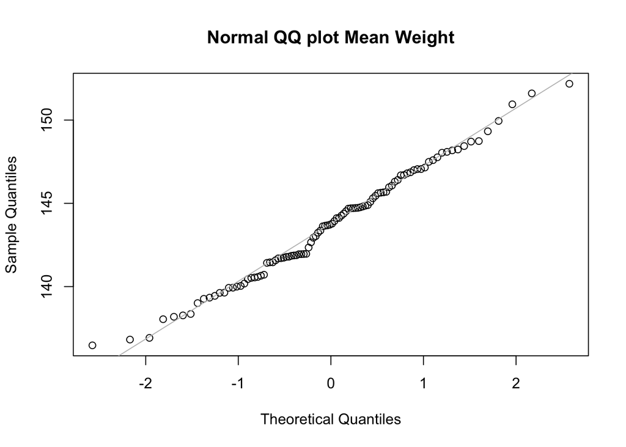

```r
qqnorm(sampledist$SUR_99meanweight, main = "Normal QQ plot Mean Weight")
qqline(sampledist$SUR_99meanweight, col = "gray")
```

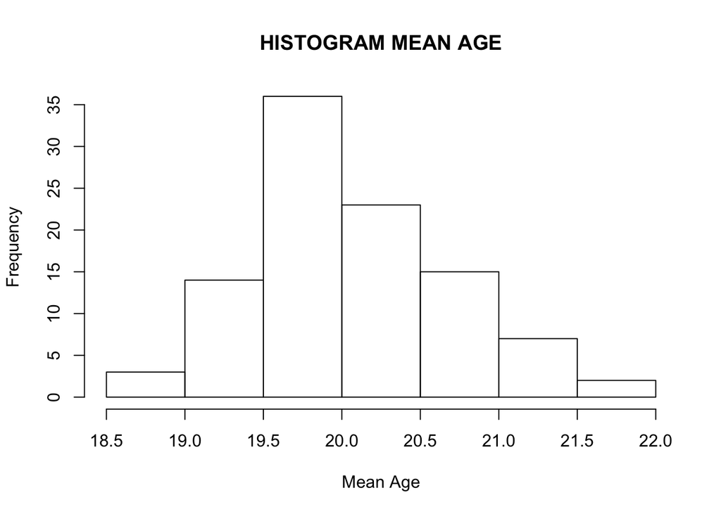

```r
hist(sampledist$SUR_99meanage, main= "HISTOGRAM MEAN AGE", xlab="Mean Age")
```

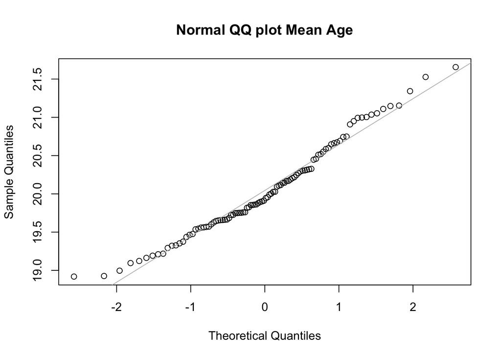

```r
qqnorm(sampledist$SUR_99meanage, main = "Normal QQ plot Mean Age")
qqline(sampledist$SUR_99meanage, col = "gray")
```

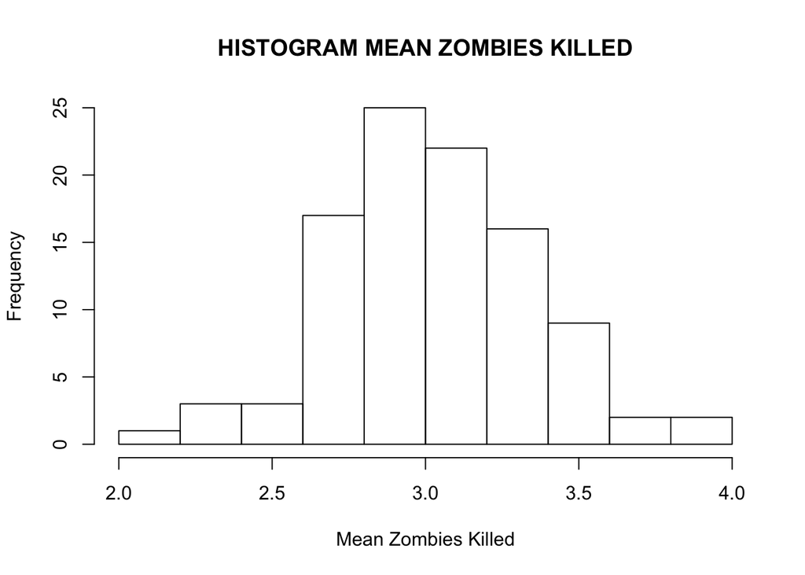

```r
hist(sampledist$SUR_99meanzombieskilled, main= "HISTOGRAM MEAN ZOMBIES KILLED", xlab="Mean Zombies Killed")
```

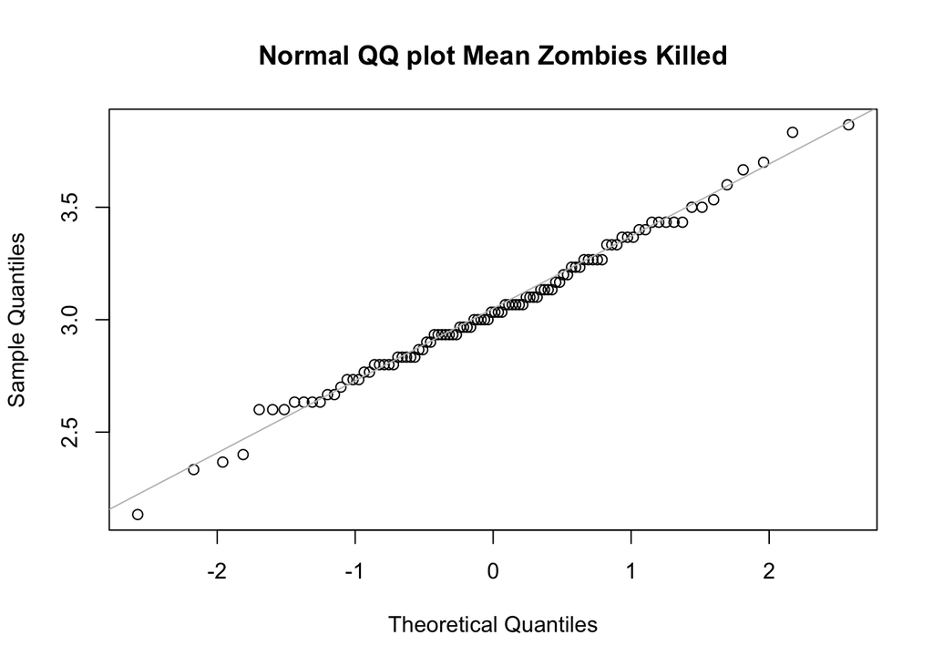

```r
qqnorm(sampledist$SUR_99meanzombieskilled, main = "Normal QQ plot Mean Zombies Killed")
qqline(sampledist$SUR_99meanzombieskilled, col = "gray")
```

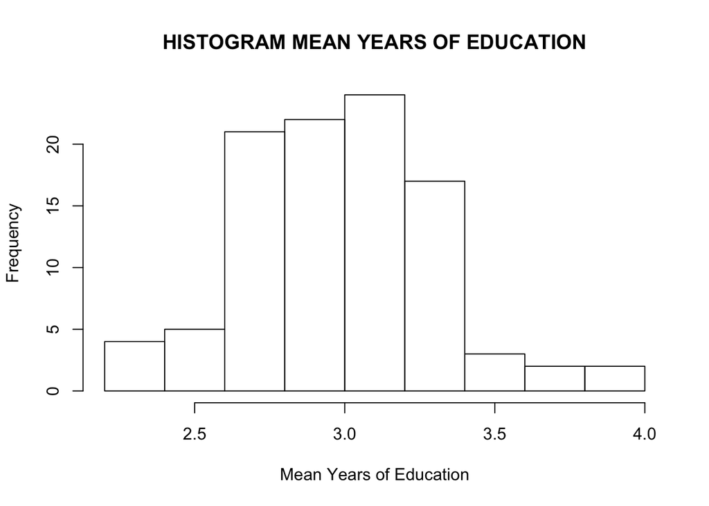

```r
hist(sampledist$SUR_99meanyearsedu, main= "HISTOGRAM MEAN YEARS OF EDUCATION", xlab="Mean Years of Education")
```

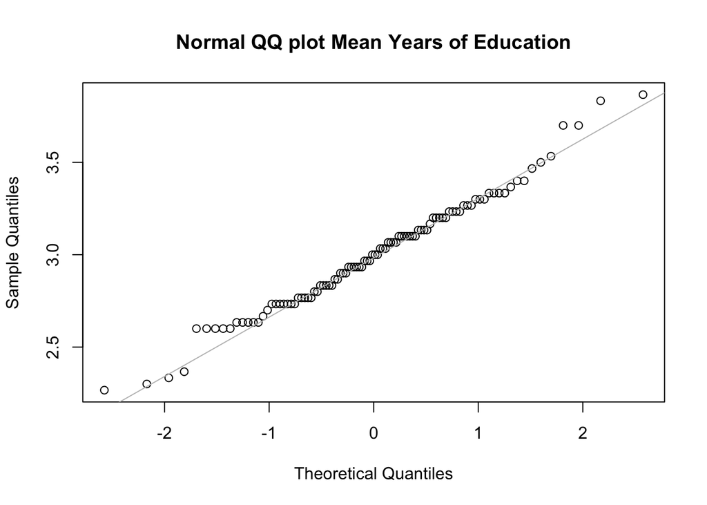

```r
qqnorm(sampledist$SUR_99meanyearsedu, main = "Normal QQ plot Mean Years of Education")
qqline(sampledist$SUR_99meanyearsedu, col = "gray")
```